# rRNADepletion_hypoxia

Lachlan Baer

08 October, 2020

# Setup

```r
library(tidyverse)
library(magrittr)
library(ngsReports)
library(here)
library(scales)
library(ggpubr)
library(kableExtra)
library(AnnotationHub)
library(ensembldb)
library(edgeR)
library(corrplot)
library(DT)
library(pander)
library(ggrepel)
library(pheatmap)
library(ggdendro)
```

```r
if (interactive()) setwd(here::here())
theme_set(theme_bw())
```

## Sequence information

```r
ah_Dr <- AnnotationHub() %>%
  subset(species == "Danio rerio") %>%
  subset(rdataclass == "EnsDb")
ensDb_Dr <- ah_Dr[["AH83189"]]
trEns_Dr <- transcripts(ensDb_Dr) %>%
  mcols() %>%
  as_tibble()
trLen_Dr <- exonsBy(ensDb_Dr, "tx") %>%
  width() %>%
  vapply(sum, integer(1))
geneGcLen_Dr <- trLen_Dr %>%
  enframe() %>%
  set_colnames(c("tx_id", "length")) %>%
  left_join(trEns_Dr) %>%
  group_by(gene_id) %>%
  summarise(
    aveLen = mean(length),
    maxLen = max(length),
    aveGc = sum(length * gc_content) / sum(length),
    longestGc = gc_content[which.max(length)[[1]]]
  ) %>%
  mutate(
    aveGc =  aveGc / 100,
    longestGc = longestGc / 100
  )
trGcLen_Dr <- trLen_Dr %>%
  enframe() %>%
  set_colnames(c("tx_id", "length")) %>%
  left_join(trEns_Dr) %>%
  group_by(tx_id) %>%
  summarise(
    aveLen = mean(length),
    maxLen = max(length),
    aveGc = sum(length * gc_content) / sum(length),
    longestGc = gc_content[which.max(length)[[1]]]
  ) %>%
  mutate(
    aveGc =  aveGc / 100,
    longestGc = longestGc / 100
  )
genesGR_Dr <- genes(ensDb_Dr)
mcols(genesGR_Dr) <- mcols(genesGR_Dr)[c("gene_id", "gene_name",
                                         "gene_biotype", "entrezid")]
txGR_Dr <- transcripts(ensDb_Dr)
mcols(txGR_Dr) <- mcols(txGR_Dr)[c("tx_id", "tx_name",
                                   "tx_biotype", "tx_id_version", "gene_id")]
```

An `EnsDb` object was obtained for Ensembl release 101 using the `AnnotationHub` package. This provided the GC content and length for every gene and transcript in the release. For zebrafish, this consists of 37241 genes and 65905 transcripts.

# Raw data

This is a polyA RNA-seq dataset generated from two families of zebrafish at different ages, 6 and 24 months. Both families consist of sibling WT zebrafish (*Danio rerio*) and heterozygous mutants (psen1<sup>Q96K97del/+</sup>), and samples were generated from these fish under both normal conditions and hypoxic stress. This dataset is intended to be used as a negative control for differential k-mer expression in comparison to the psen2S4ter dataset. [Previous analysis](https://github.com/UofABioinformaticsHub/20170906_Morgan_Hypoxia) showed strong DE signal between WT fish under normal conditions compared to those under hypoxic stress in both age groups. The 6-month fish from this dataset will therefore be investigated for differential expression of k-mers, to identify whether differential expression of k-mers is a function of differential gene expression.

## Sample information

```r
files <- list.files(
  path = "/hpcfs/users/a1647910/20200910_Hypoxia/0_rawData/FastQC",
  pattern = "zip",
  full.names = TRUE
)
```

```r
samples <- tibble(
  sample = str_remove(basename(files), "_fastqc.zip"),
  dataset = NA,
  organism = NA
) %>%
  mutate(
    dataset = "Hypoxia",
    organism = "zebrafish"
  )
datasets <- samples$dataset %>%
  unique()
```

The following analysis involves 8 single-end samples across 1 dataset(s): Hypoxia.

## Library sizes

```r
rawFqc <- files %>%
  FastqcDataList()
```

```r
data <- grep("", fqName(rawFqc))
labels <- rawFqc[data] %>%
  fqName() %>%
  str_remove("[0-9]+-MORGAN-6P-") %>%
  str_remove("\\.fastq\\.gz") %>%
  str_remove("_S[0-9]+_R1_001")
rawLib <- plotReadTotals(rawFqc[data]) +
  labs(subtitle = "Hypoxia") +
  scale_x_discrete(labels = labels)
```

The library sizes of the unprocessed dataset(s) range between 26,302,897 and 48,869,955 reads.

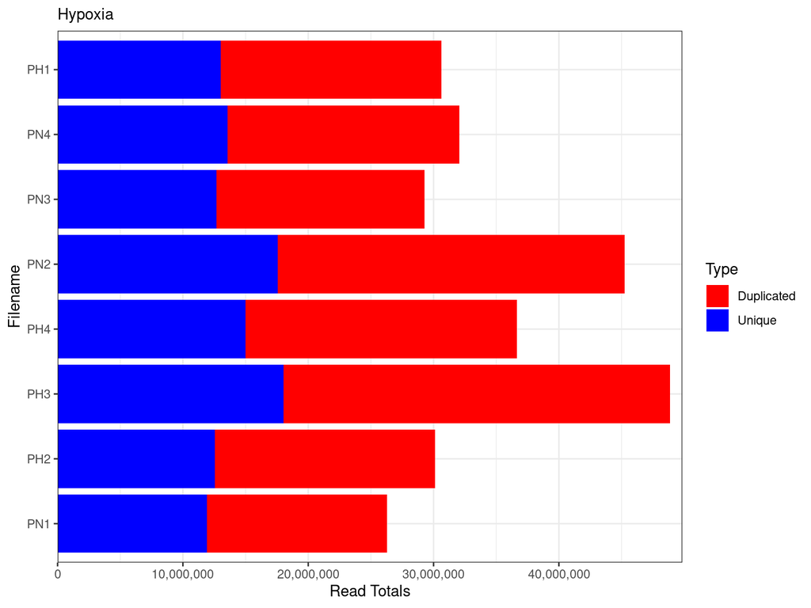

```r
rawLib
```

# Trimmed data

Raw libraries were trimmed using `cutadapt v1.14` to remove Illumina adapter sequences. Bases with PHRED score < 30, NextSeq-induced polyG runs and reads shorter than 35bp were also removed.

```r
trimFqc <- list.files(
  path = "/hpcfs/users/a1647910/20200910_Hypoxia/1_trimmedData/FastQC",
  pattern = "zip",
  full.names = TRUE
) %>%
  FastqcDataList()
trimStats <- readTotals(rawFqc) %>%
  dplyr::rename(Raw = Total_Sequences) %>%
  left_join(readTotals(trimFqc), by = "Filename") %>%
  dplyr::rename(Trimmed = Total_Sequences) %>%
  mutate(
    Discarded = 1 - Trimmed/Raw,
    Retained = Trimmed / Raw
  )
```

After trimming of adapters between 1.28% and 2.14% of reads were discarded.

# Aligned data

Trimmed reads were:

1. Aligned to rRNA sequences using the `BWA-MEM` algorithm to estimate the proportion of reads that were of rRNA origin within each sample. `BWA-MEM` is recommended for high-quality queries of reads ranging from 70bp to 1Mbp as it is faster and more accurate that alternative algorithms `BWA-backtrack` and `BWA-SW`.
2. Aligned to the *Danio rerio* GRCz11 genome (Ensembl release 101) using `STAR v2.7.0d` and summarised with `featureCounts` from the `Subread v1.5.2` package. These counts were used for all gene-level analysis.

## rRNA proportions

```r
bwaMapped <- read.delim(
  "/hpcfs/users/a1647910/20200910_Hypoxia/3_bwa/log/samples.mapped.all",
  sep = ":",
  col.names = c("sample", "proportion"),
  header = FALSE
) %>%
  mutate(
    sample = str_remove(sample, ".mapped"),
    sample = basename(sample),
    proportion = proportion/100
  )
rRnaProp <- samples %>%
  dplyr::filter(dataset == "Hypoxia") %>%
  left_join(bwaMapped) %>%
  mutate(
    sample = str_remove(sample, "[0-9]+-MORGAN-6P-"),
    sample = str_remove(sample, "_S[0-9]+_R1_001"),
    group = str_extract(sample, "(N|H)")
  )
rRnaProp$dataset %<>%
  factor(levels = c("Hypoxia"))
```

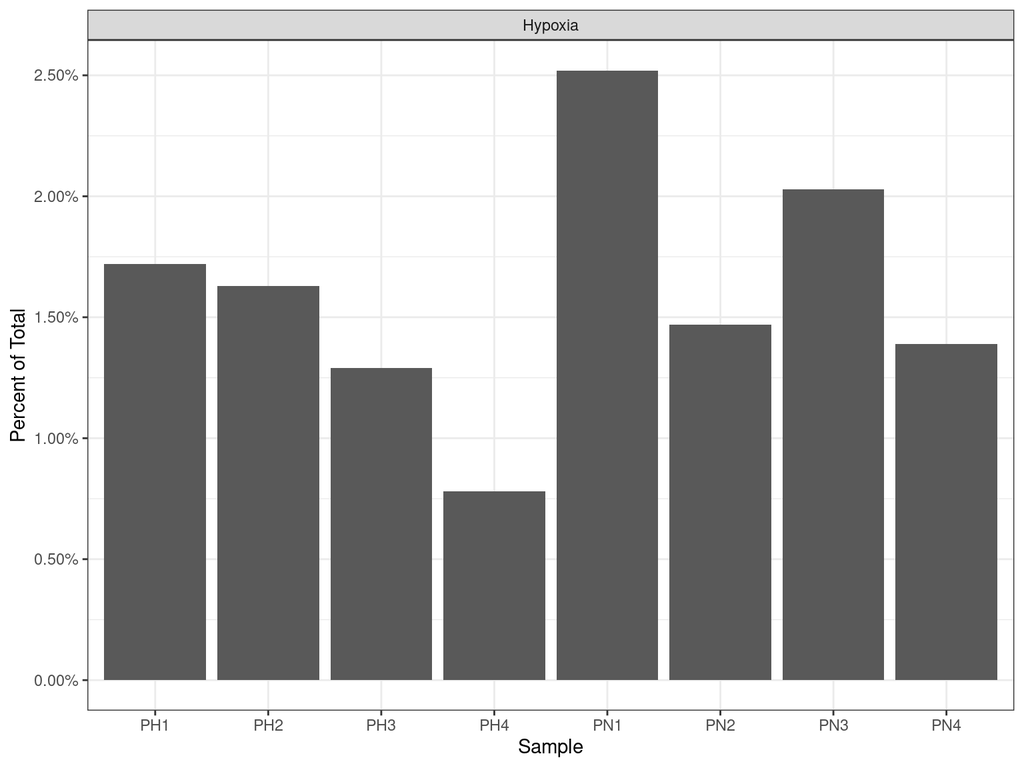

*Percentages of each library that align to rRNA sequences with `bwa mem`.*

```r
rRnaProp %>%
  ggplot(aes(sample, proportion)) +
  geom_bar(stat = "identity", position = "dodge") +
  facet_wrap(~dataset, scales = "free_x") +
  scale_y_continuous(labels = percent) +
  labs(x = "Sample", y = "Percent of Total")
```

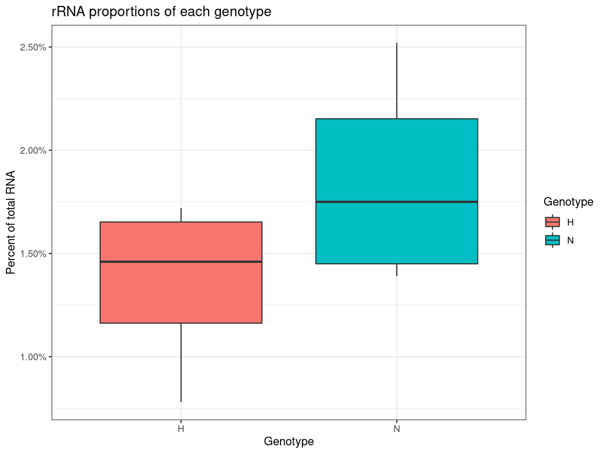

```r
rRnaProp %>%
  ggplot(aes(group, proportion, fill = group)) +
  geom_boxplot() +
  scale_y_continuous(labels = percent) +
  labs(x = "Genotype", y = "Percent of total RNA", title = "rRNA proportions of each genotype") +
  scale_fill_discrete(
    name = "Genotype"
  )
```

## Gene GC content and length

```r
dgeList <- read_tsv("/hpcfs/users/a1647910/20200910_Hypoxia/2_alignedData/featureCounts/genes.out") %>%
  set_colnames(basename(colnames(.))) %>%
  set_colnames(str_remove(colnames(.), "Aligned.sortedByCoord.out.bam")) %>%
  set_colnames(str_remove(colnames(.), "[0-9]+-MORGAN-6P-")) %>%
  set_colnames(str_remove(colnames(.), "_S[0-9]+_R1_001")) %>%
  as.data.frame() %>%
  column_to_rownames("Geneid") %>%
  DGEList() %>%
  calcNormFactors()
```

```r
dgeList$genes <- genesGR_Dr[rownames(dgeList),]
mcols(dgeList$genes) %<>%
  as.data.frame() %>%
  left_join(geneGcLen_Dr)
addInfo <- tibble(
  sample = rRnaProp$sample,
  dataset = "Hypoxia",
  organism = "zebrafish",
  rRNA = rRnaProp$proportion
)
dgeList$samples %<>%
  rownames_to_column("rowname") %>%
  mutate(sample = rowname) %>%
  left_join(addInfo) %>%
  column_to_rownames("rowname")
dgeList$samples$filenames <- read_tsv(
  "/hpcfs/users/a1647910/20200910_Hypoxia/2_alignedData/featureCounts/genes.out"
) %>%
  dplyr::select(-Geneid) %>%
  colnames()
dgeList$samples$group <- colnames(dgeList) %>%
  str_extract("(N|H)") %>%
  factor(levels = c("N", "H"))
```

```r
gcInfo <- function(x) {
  x$counts %>%
    as.data.frame() %>%
    rownames_to_column("gene_id") %>%
    as_tibble() %>%
    pivot_longer(
      cols = colnames(x),
      names_to = "sample",
      values_to = "counts"
    ) %>%
    dplyr::filter(
      counts > 0
    ) %>%
    left_join(
      geneGcLen_Dr
    ) %>%
    dplyr::select(
      ends_with("id"), sample, counts, aveGc, maxLen
    ) %>%
    split(f = .$sample) %>%
    lapply(
      function(x){
        DataFrame(
          gc = Rle(x$aveGc, x$counts),
          logLen = Rle(log10(x$maxLen), x$counts)
        )
      }
    )
}
gcSummary <- function(x) {
  x %>%
    vapply(function(x){
      c(mean(x$gc), sd(x$gc), mean(x$logLen), sd(x$logLen))
    }, numeric(4)
    ) %>%
    t() %>%
    set_colnames(
      c("mn_gc", "sd_gc", "mn_logLen", "sd_logLen")
    ) %>%
    as.data.frame() %>%
    rownames_to_column("sample") %>%
    as_tibble()
}
```

```r
rle <- gcInfo(dgeList)
```

```r
sumGc <- gcSummary(rle)
```

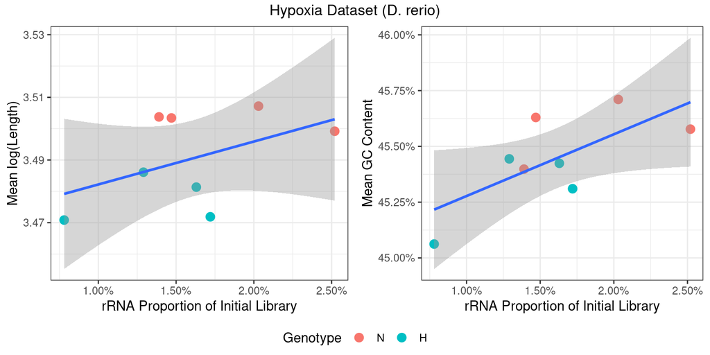

*Comparison of residual bias potentially introduced by incomplete rRNA removal. Regression lines are shown along with standard error bands for each comparison.*

```r
a <- sumGc %>%
  left_join(dgeList$samples) %>%
  ggplot(aes(rRNA, mn_logLen)) +
  geom_point(aes(colour = group), size = 3) +
  geom_smooth(method = "lm") +
  scale_x_continuous(labels = percent) +
  labs(
    x = "rRNA Proportion of Initial Library",
    y = "Mean log(Length)",
    colour = "Genotype"
  )
b <- sumGc %>%
  left_join(dgeList$samples) %>%
  ggplot(aes(rRNA, mn_gc)) +
  geom_point(aes(colour = group), size = 3) +
  geom_smooth(method = "lm") +
  scale_y_continuous(labels = percent) +
  scale_x_continuous(labels = percent) +
  labs(
    x = "rRNA Proportion of Initial Library",
    y = "Mean GC Content",
    colour = "Genotype"
  )
ggarrange(
  a, b, ncol = 2, nrow = 1,
  common.legend = TRUE, legend = "bottom"
) %>%
  annotate_figure("Hypoxia Dataset (D. rerio)")
```

## PCA

```r
genes2keep <- dgeList %>%
  cpm() %>%
  is_greater_than(1) %>%
  rowSums() %>%
  is_weakly_greater_than(4)
dgeFilt <- dgeList[genes2keep,, keep.lib.sizes = FALSE] %>%
  calcNormFactors()
```

```r
pca <- cpm(dgeFilt, log = TRUE) %>%
  t() %>%
  prcomp()
```

```r
pcaCor <- pca$x %>%
  as.data.frame() %>%
  rownames_to_column("sample") %>%
  left_join(sumGc) %>%
  as_tibble() %>%
  left_join(dgeList$samples) %>%
  dplyr::select(
    PC1, PC2, PC3,
    Mean_GC = mn_gc,
    Mean_Length = mn_logLen,
    rRna_Proportion = rRNA
  ) %>%
  cor()
```

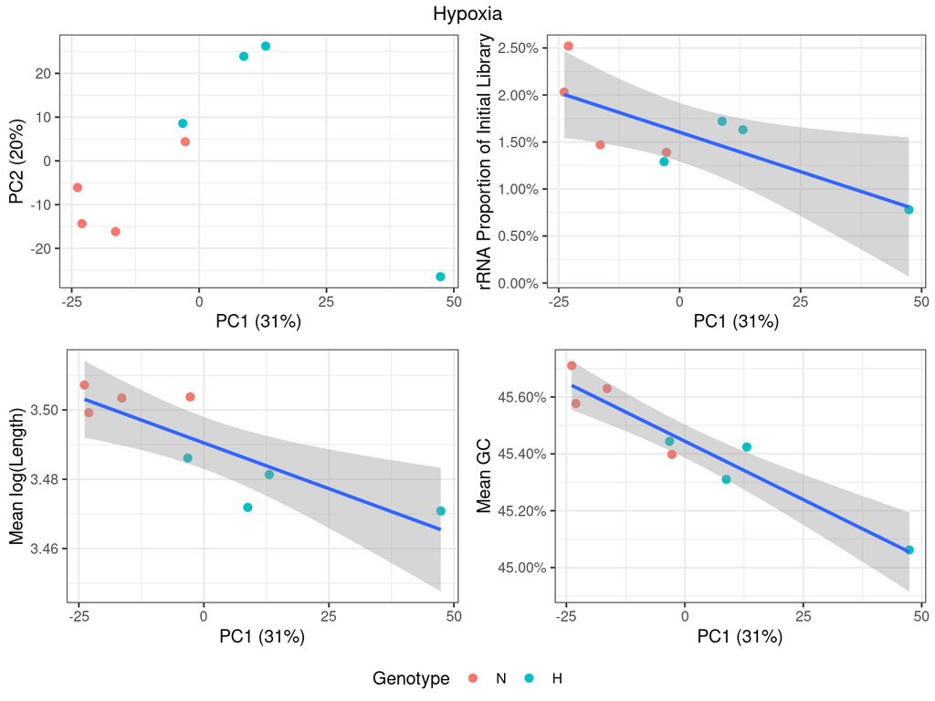

*PCA plot showing rRNA proportion, mean GC content and mean log(length) after summarisation to gene-level.*

```r
a <- pca$x %>%
  as.data.frame() %>%
  rownames_to_column("sample") %>%
  left_join(dgeList$samples) %>%
  as_tibble() %>%
  ggplot(aes(PC1, PC2)) +
  geom_point(aes(colour = group), size = 2) +
  labs(
    x = paste0("PC1 (", percent(summary(pca)$importance["Proportion of Variance","PC1"]),")"),
    y = paste0("PC2 (", percent(summary(pca)$importance["Proportion of Variance","PC2"]),")"),
    colour = "Genotype"
  )
b <- pca$x %>%
  as.data.frame() %>%
  rownames_to_column("sample") %>%
  left_join(dgeList$samples) %>%
  ggplot(aes(PC1, rRNA)) +
  geom_point(aes(colour = group), size = 2) +
  geom_smooth(method = "lm") +
  scale_y_continuous(labels = percent) +
  labs(
    x = paste0("PC1 (", percent(summary(pca)$importance["Proportion of Variance","PC1"]),")"),
    y = "rRNA Proportion of Initial Library",
    colour = "Genotype"
  )
c <- pca$x %>%
  as.data.frame() %>%
  rownames_to_column("sample") %>%
  left_join(sumGc) %>%
  left_join(dgeList$samples) %>%
  as_tibble() %>%
  ggplot(aes(PC1, mn_logLen)) +
  geom_point(aes(colour = group), size = 2) +
  geom_smooth(method = "lm") +
  labs(
    x = paste0("PC1 (", percent(summary(pca)$importance["Proportion of Variance","PC1"]),")"),
    y = "Mean log(Length)",
    colour = "Genotype"
  )
d <- pca$x %>%
  as.data.frame() %>%
  rownames_to_column("sample") %>%
  left_join(sumGc) %>%
  left_join(dgeList$samples) %>%
  as_tibble() %>%
  ggplot(aes(PC1, mn_gc)) +
  geom_point(aes(colour = group), size = 2) +
  geom_smooth(method = "lm") +
  scale_y_continuous(labels = percent) +
  labs(
    x = paste0("PC1 (", percent(summary(pca)$importance["Proportion of Variance","PC1"]),")"),
    y = "Mean GC",
    colour = "Genotype"
  )
ggarrange(
  a, b, c, d, ncol = 2, nrow = 2,
  common.legend = TRUE, legend = "bottom"
) %>%
  annotate_figure("Hypoxia")
```

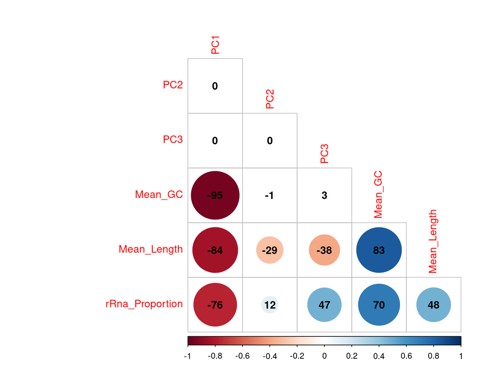

*Correlations between the first three principal components and measured variables: mean GC content, mean log(length) and rRNA proportion.*

```r
corrplot(
  pcaCor,
  type = "lower",
  diag = FALSE,
  addCoef.col = 1, addCoefasPercent = TRUE
)
```